# Phylogenetic Tree Representation

Eric Marcon

AgroParisTech, UMR EcoFoG

eric.marcon@ecofog.gf

22 novembre 2017

#### Abstract

Several object classes can be used in *entropart* to represent phylogenies and calculate phylogenetic diversity. They are detailed here.

#### Package

entropart 1.4.8

# 1 Formats used

Supported phylogenies are classes `phylo` from package *ape*, `phylog` from package *ade4* and `hclust` from package *base*.

To optimize performance, a specific class `PPtree`, for “preprocessed trees”, is introduced by the package: it is basically a list containing a `phylo` and an `hclust` representation of the phylogeny and preprocessed useful statistics.

The arguments `Tree` or `PhyloTree` used in phylogenetic diversity estimation functions of the package may be any of those formats.

# 2 Conversion between classes

Let’s start from an ultrametric distance matrix. Three species are defined, with distance 1 between the first 2 and distance 2 between both and the last one.

```r
dSp <- matrix(c(0, 1, 2, 1, 0, 2, 2, 2, 0), nrow=3, byrow=TRUE)
row.names(dSp) <- colnames(dSp) <- c("A", "B", "C")
dSp
```

```
##   A B C
## A 0 1 2
## B 1 0 2
## C 2 2 0
```

## 2.1 hclust

An `hclust` object is created by UPGMA hierarchical clustering.

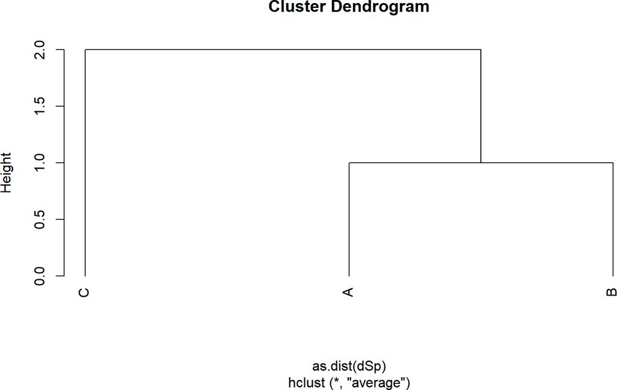

```r
require("stats")
plot(hTree <- hclust(as.dist(dSp), method="average"), hang=-0.01, axes = F)
axis(2)
```

Node heights are stored in `$height`.

```r
hTree$height
```

```
## [1] 1 2
```

## 2.2 phylo

Conversion to a `phylo` object is straightforward.

```r
require("ape")
```

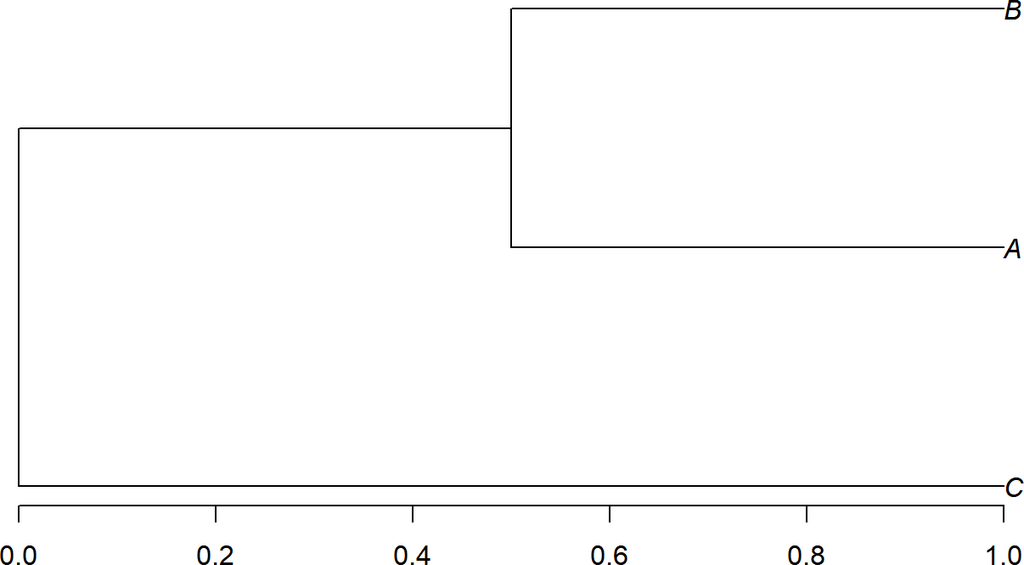

```r
plot(phyloTree <- as.phylo(hTree))
axis(1)
```

Edge lengths have been divided by 2 during the conversion, as documented in `?as.phylo.hclust`.

```r
phyloTree$edge.length
```

```
## [1] 1.0 0.5 0.5 0.5
```

That does not suit our needs. In *entropart*, edge lengths are multiplied by 2 after conversion, so that `phylo`objects can be identical to other phylogenies.

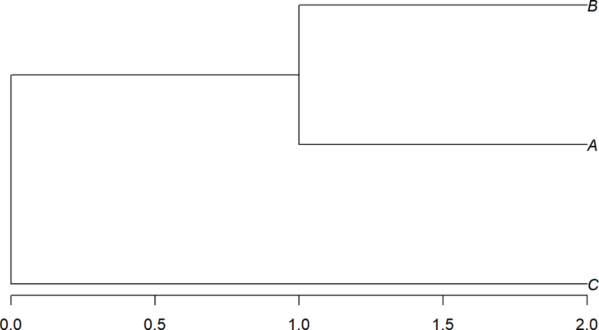

```r
phyloTree$edge.length <- 2*phyloTree$edge.length
plot(phyloTree)
axis(1)
```

## 2.3 phylog

```r
require("ade4")
```

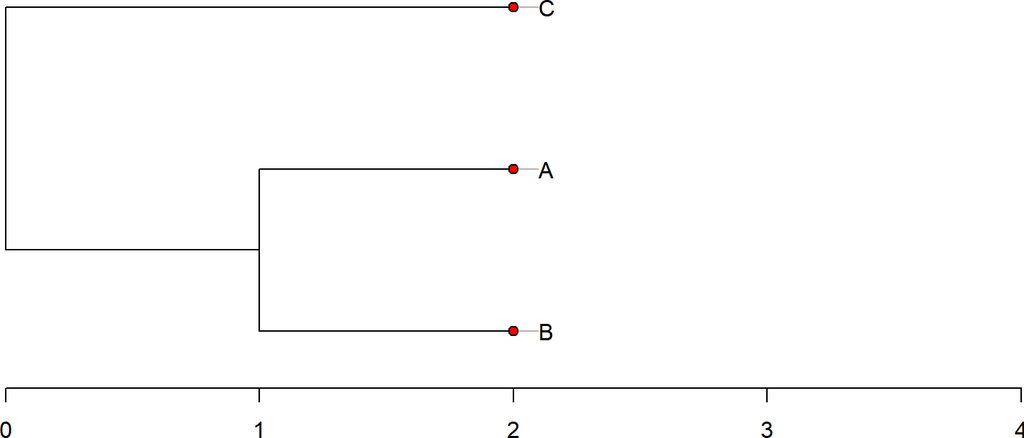

```r
plot(phylogTree <- hclust2phylog(hTree))
axis(1)
```

```r
phylogTree$droot
```

```
##    C    A    B Int1 Root
##    2    2    2    1    0
```

```r
phylogTree$Wdist^2/2
```

```
##   C A
## A 2
## B 2 1
```

# 3 Newick dendrograms

A Newick description of a dendrogram can read into a `phylo` object.

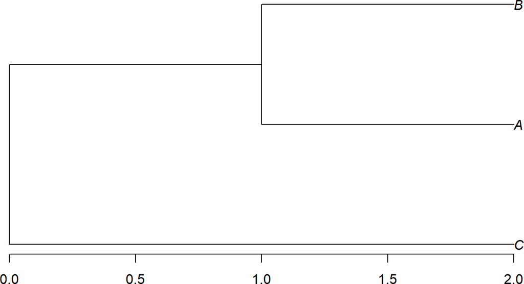

```r
NewickABC <- "(C:2,(A:1,B:1):1);"
plot(phyloABC <- ape::read.tree(text=NewickABC))
axis(1)
```